```python
%%html
<style>table {float:left}</style>
<script>
code_show=false;
function code_toggle(){
    if(code_show){$('.prompt, .input, .output_stderr, .output_error').hide();}
    else{$('.input, .prompt, .output_stderr, .output_error').show();}
    code_show=!code_show;
}
function initialize(){
    var output=$('.output_subarea.output_text.output_stream.output_stdout');
    $.merge(output,$('.output_subarea.output_text.output_result'));
    for(var i=0;i<output.length;i++)for(var j=0;j<output[i].children.length;j++)
        output[i].children[j].style.fontFamily='Palatino';
    code_toggle();
}
$(document).ready(initialize);
</script>
<a href="javascript:code_toggle()">Click here to show/hide code</a >
```

Click here to show/hide code

# SPX Volatility Term Structure Analysis

In this exercise we analyze the SPX volatility structure based on daily close prices over the period of 1970-2018. We rely on the Black-Scholes framework and the Dupire formula to calibrate our volatility curve parameters to fit the historical SPX return distribution.

## 1. Theoretical Discussion

We start off by assuming that the local volatility is a function of the log-in-the-moneyness $x$ for a fixed maturity window of $T$ business days.

$$ \sigma(x) = g(x) \\ \text{ where } x=log(K/S_0)$$

Under the Black-Scholes framework with risk-free rate $r=0$, a call option premium for $S_0=1$ is:

$$ C(K, T) = \Phi(d1) - K\Phi(d2) \\ d_{\text{1, 2}} = \dfrac{log(1/K) \pm (\sigma^2/2)T}{\sigma\sqrt{T}} $$

If we assume that there exists a probability density function $f_{S_T}$, we have:

$$ C(K, T) = \int^{\infty}_K(S_T-K)f_{S_T}(S_T)dS_T $$

Taking partial derivative w.r.t. $K$, we get the Dupire formula:

$$ \dfrac{\partial C}{\partial K} = \int^{\infty}_K -f_{S_T}(S_T)dS_T \\ \dfrac{\partial^2 C}{\partial K^2} = f_{S_T}(K) $$

We can approximate the second-order derivative numerically:

$$ f_{S_T}(K) \approx \dfrac{C(K + \Delta K) - 2C(K) + C(K - \Delta K)}{(\Delta K)^2} $$

We previously defined that $x = log(K)$. Given any $\Delta K$, let us define $\Delta x$ such that:

$$ \Delta x = \dfrac{\Delta K}{K} \\ \text{therefore, } \Delta K = e^{x}\Delta x $$

We define $r_T$ as the $T$ period log return, and that $r_T=log(S_T)$. Based on chain rule:

$$ f_{r_T}(x) = f_{S_T}(K) \times K $$

So in conclusion we have:

$$ f_{r_T}(x) = f_{S_T}(K) \times K \approx \dfrac{C(e^x + e^x\Delta x) - 2C(e^x) + C(e^x - e^x\Delta x)}{e^x(\Delta x)^2} \\ \text{where } C(x) = \Phi(\dfrac{-x + (\sigma(x)^2/2)T}{\sigma(x)\sqrt{T}}) - e^x\Phi(\dfrac{-x - (\sigma(x)^2/2)T}{\sigma(x)\sqrt{T}}) \text{, and } \sigma(x) = g(x) $$

The goal is to find the optimal volatility function $g(x)$ such that $f_{r_T}(x)$ fits to the historical distribution of $r_T$.

[figure not shown]

## 2. Data and Limitation

### 2.1 Data

Plotting the daily log return over the entire data period.

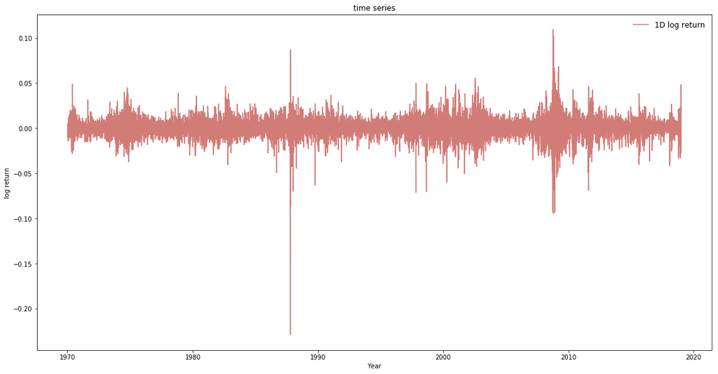

```python
# too many windows, only display six
cm = {'g':'#60854B', 'r':'#C75B56', 'b':'#6C8DBF'}
fig = plt.figure(figsize=(16, 32))

ax = fig.add_subplot(4, 1, 1)

for term in terms.keys():
    ax.plot(df[term+"_ret"], color=cm['r'], label=term+" log return", alpha=.8)

plt.title("time series")
plt.xlabel('Year')
plt.ylabel('log return')
plt.legend(frameon=False, prop={'size': 12})
plt.tight_layout()
```

## 3. Term Structure Fitting

### 3.1 Ordinary Least Square

#### 3.1.1 Use Entire Dataset

We fit the realized return distribution with least square method.

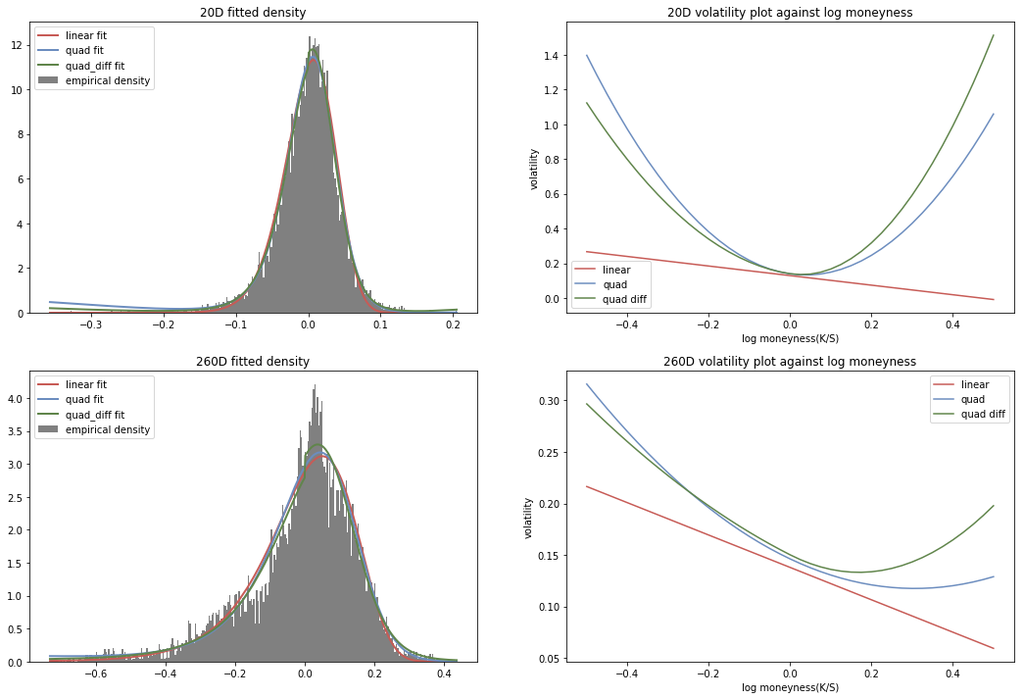

```python
sampled_ols_result = full_model_plot({'20D': 20, '260D': 260}, df, method='ols')
```

Plotting the term structure of skewness with the following definition:

$$ Skewness = \dfrac{\sigma_{20\Delta put} - \sigma_{20\Delta call}}{\text{log-moneyness}_{20\Delta put} - \text{log-moneyness}_{20\Delta call}} $$

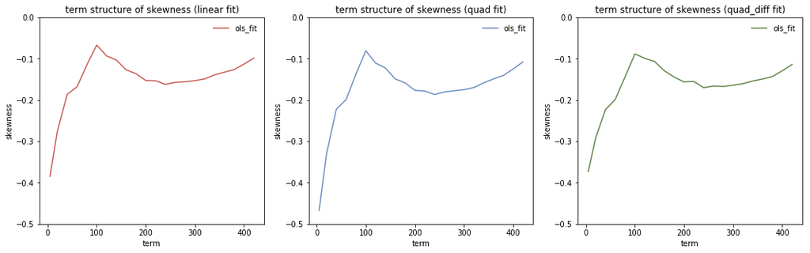

```python
plot_skew_term_structure(ols_result.iloc[:-5, :], legend=['ols_fit'], ylim=(-0.5, 0))
```

Click here to view additional code

#### 3.1.2 Bootstrapping (Resampling)

We choose the lower and upper bound randomly, covering both centered values and extreme values**

- $k$: uniformly distributed between 0.5 and 1.2
- $r$ equidistant samples from $[\mu - 5 k \sigma, \mu + 5 k \sigma]$

[figure not shown]

- In each sample, 200 points are selected.
- 40 different sets of samples were used for fitting the curve.

We then plot the term structure of skewness with resampling.

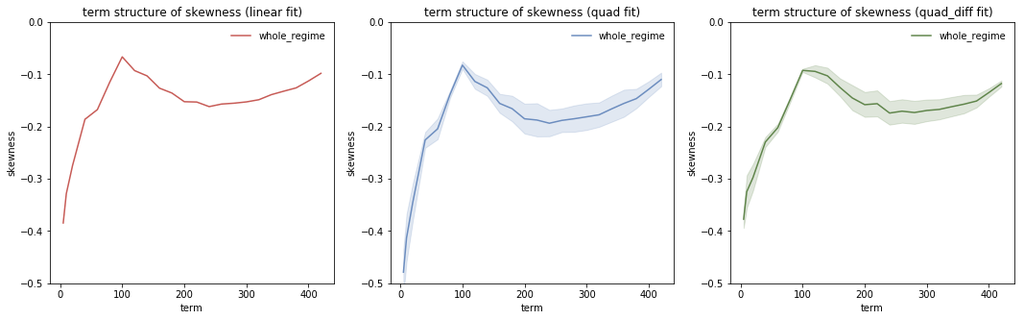

```python
plot_skew_term_structure(ols_params.iloc[:-5, :], ols_param_std.iloc[:-5, :], delta_skew=True, ylim=(-0.5, 0))
```

Click here to view additional code

### 3.1.3 Volatility Regime

We create three different regimes over the entire time horizon by looking at the one-year trailing volatility of daily log return, with cut off volatility value of 0.12 nad 0.22.

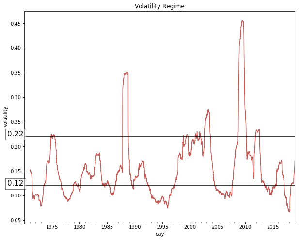

```python
df1=df.copy()
mov_vol = df1['r'].rolling(260).std()*(260)**0.5
fig = plt.figure(figsize=(10, 8))
mov_vol.plot(color='#C75B56')
plt.axhline(y=0.12, color='black')
plt.axhline(y=0.22, color='black')
plt.text(-800, 0.12, "0.12", bbox=dict(facecolor="w",alpha=0.5),fontsize=15)
plt.text(-800, 0.22, "0.22", bbox=dict(facecolor="w",alpha=0.5),fontsize=15)
plt.title('Volatility Regime')
plt.xlabel('day');
plt.ylabel('volatility');
```

We then plot the term structure of skewness by regimes.

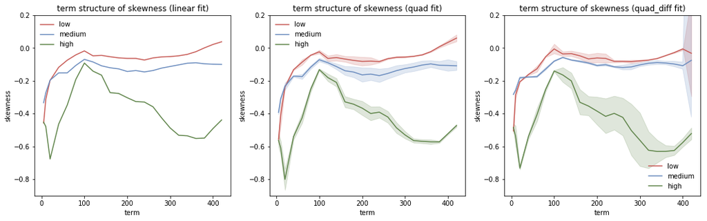

```python
plot_skew_term_structure(ols_params, ols_params_std, legend=['low','medium','high'],delta_skew=True)
```

Click here to view additional code

### 3.2 Maximum Likelihood Estimation

For best fitting results, here we use SVI to model volatility. Specifically, the SVI model can be stated as:

$$Var(x) = a + b * (\rho * (x - m) + \sqrt{(x-m)^2 + \sigma^2})$$

We would like to find optimal set of ($a$, $b$, $\rho$, $m$, $\sigma$) that fits best to empirical return distribution.

Furthermore, we would like to add additional constriants to ensure we do not get negative volatility and probability density:

$$a+b\sigma \sqrt{1-\rho ^2}\geq 0$$$$b(1+\left | \rho \right |)\leq \frac{2}{T}$$$$b(1+\left | \rho \right |)\leq 2$$

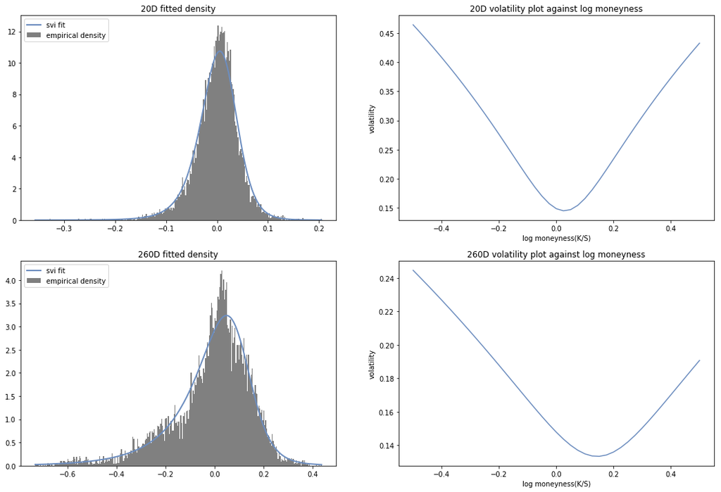

```python
result_partial=full_model({'20D':20,'260D':260}, df, plot=True, method='mle')
```

We plot the term structure of skewness with the same definition:

$$ Skewness = \dfrac{\sigma_{20\Delta put} - \sigma_{20\Delta call}}{\text{log-moneyness}_{20\Delta put} - \text{log-moneyness}_{20\Delta call}} $$

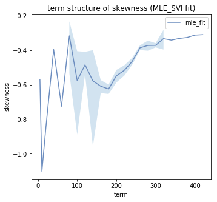

```python
plot_svi_skew(mle_params, mle_param_std, legend=['mle_fit'],delta_skew=True)
```

Click here to view additional code

## 4. Further Study

Additional analysis - volatility reversion.

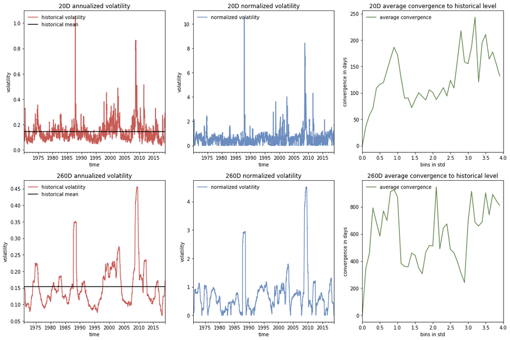

```python
fig = plt.figure(figsize=(18, len(terms) * 6))
cm = {'g':'#60854B', 'r':'#C75B56', 'b':'#6C8DBF'}
index = 1

for term_str, term_day in terms.items():
    # fit kernel density
    vol_raw = df['vol_' + term_str].dropna()
    vol_mean, vol_std = vol_raw.mean(), vol_raw.std()

    # normalization
    vol_norm = (vol_raw - vol_mean) / vol_std
    vol_norm = abs(vol_norm)
    #vol_raw_abs = abs(vol_raw)
    #vol_mean_abs = vol_raw_abs.mean()
    #vol_mean_abs = (vol_mean_abs - vol_mean) / vol_std

    temp = pd.DataFrame(vol_norm)
    temp.index.name = "Date"
    temp.columns = ["Normalized Volatility"]
    # set the convergence to be plus/minus 0.1 of standard deviation
    convergence = 0.1
    temp = temp[temp["Normalized Volatility"] < convergence]

    # bins
    bins = {round(b, 1):[] for b in np.arange(0, 4.1, 0.1)}

    for time, vol in vol_norm.items():
        if vol < 0.1:
            bins[0.0].append(0)
        elif vol > 4.0:
            continue
        else:
            tempp = temp[temp.index > time]
            if tempp.empty == True:
                break
            else:
                days = (tempp.index[0] - time).days
                bins[round(vol//0.1*0.1, 1)].append(days)
    for i in bins.keys():
        bins[i] = np.mean(bins[i])

    avg_conv = pd.DataFrame(bins, index=["Average Convergence"]).T
    avg_conv.index.name = "bins"

    # plotting results
    ax = fig.add_subplot(len(terms), 3, 3*index-2)
    vol_raw.plot(ax=ax, color=cm['r'])
    ax.axhline(y=vol_mean, color='black')
    ax.legend(['historical volatility', 'historical mean'], loc='upper left', frameon=False)
    ax.set_xlabel('time')
    ax.set_ylabel('volatility')
    ax.set_title(term_str + " annualized volatility")

    ax = fig.add_subplot(len(terms), 3, 3*index-1)
    vol_norm.plot(ax=ax, color=cm['b'])
    #ax.axhline(y=vol_mean_abs, color='g')
    #ax.legend(['normalized volatility', 'vol_mean_abs'], loc='upper left', frameon=False)
    ax.legend(['normalized volatility'], loc='upper left', frameon=False)
    ax.set_xlabel('time')
    ax.set_ylabel('volatility')
    ax.set_title(term_str + " normalized volatility")

    ax = fig.add_subplot(len(terms), 3, 3*index)
    avg_conv.plot(ax=ax, color=cm['g'])
    ax.legend(['average convergence'], loc='upper left', frameon=False)
    ax.set_xlabel('bins in std')
    ax.set_ylabel('convergence in days')
    ax.set_title(term_str + " average convergence to historical level")

    index += 1
```

Click here to view additional code

Next Steps:

- Include risk-free rate in the dupire formula and the Black Scholes model.
- Heston volatility model
- Create regime based on interest rate.

```python
%%html
<script>initialize();</script>
<a href="javascript:code_toggle()">Click here to show/hide code</a >
```

Click here to show/hide code